# Statistics for Data Science Project 2021/2022 - Risk of Business Failure

Question A

# Data Preparation

We load the necessary libraries as well as the aida dataset itself, along with any needed variable obtained during the first section.

```r
library(ggplot2)
library(dplyr)
library(forcats)
```

```r
# cleaning the environment
rm(list=ls())
# loading the dataset
load(file="aida.RData")
# loading functions to be used
source("functions.R")
```

```r
# features added by using the functions in "functions.R"
aida <- getSize(aida)
aida <- getGeoArea(aida)
aida <- getStatus(aida)
aida <- getAge(aida)
aida <- getATECO(aida)
aida <- getLiquidity(aida)
aida <- getSizeClass(aida)
# separating dataset filtering by year
aida.currYr <- getCurrYr(aida)
aida.yr1 <- getYr1(aida)
aida.yr2 <- getYr2(aida)
# focusing on given years
aida2017 <- aida.currYr[aida.currYr$`Last accounting closing date` == 2017,]
aida2018 <- aida.currYr[aida.currYr$`Last accounting closing date` == 2018,]
# dataset with given years
years <- c(2017, 2018)
aida1718 <- aida.currYr[aida.currYr$`Last accounting closing date` %in% years,]
# focusing on failed companies
aida2017F <- aida2017[aida2017$Status=='Failed',]
aida2018F <- aida2018[aida2018$Status=='Failed',]
aida1718F <- aida1718[aida1718$Status=='Failed',]
```

# 3.0 Question B

Compare the distributions of size/age/other of failed companies over different years? (Using years 2017 and 2018)

- are there any shift for a specific company form (SPA, SRL, etc.)
- are there any shift for a specific location? (eg., Tuscany, Lombardy, etc.)

## 3.1 Age Distribution

Let us look at the density function of the age feature we obtained before at certain years, namely 2018, since that is the year where we have the biggest amount of information available.

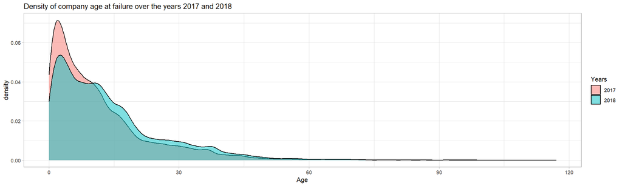

```r
# density of company age at failure over the years 2017 and 2018
ggplot(data=aida1718F, aes(x=Age, group=as.factor(`Last accounting closing date`), fill=as.factor(`Last accounting closing date`))) +
  geom_density(adjust=1, alpha=.5) +
  theme_light() +
  labs(fill = "Years") +
  ggtitle("Density of company age at failure over the years 2017 and 2018")
```

```r
# data for statistical tests, age distribution in 2018
aida2017.FailedAge <- aida2017[aida2017$Status=='Failed','Age']
aida2018.FailedAge <- aida2018[aida2018$Status=='Failed','Age']

wilcox.test(aida2017.FailedAge, aida2018.FailedAge, alternative = 'two.sided')
```

```
    Wilcoxon rank sum test with continuity correction

data:  aida2017.FailedAge and aida2018.FailedAge
W = 1.348e+09, p-value < 2.2e-16
alternative hypothesis: true location shift is not equal to 0
```

```r
wilcox.test(aida2017.FailedAge, aida2018.FailedAge, alternative = 'less')
```

```
    Wilcoxon rank sum test with continuity correction

data:  aida2017.FailedAge and aida2018.FailedAge
W = 1.348e+09, p-value < 2.2e-16
alternative hypothesis: true location shift is less than 0
```

```r
wilcox.test(aida2017.FailedAge, aida2018.FailedAge, alternative = 'greater')
```

```
    Wilcoxon rank sum test with continuity correction

data:  aida2017.FailedAge and aida2018.FailedAge
W = 1.348e+09, p-value = 1
alternative hypothesis: true location shift is greater than 0
```

```r
t.test(aida2017.FailedAge, aida2018.FailedAge, alternative = 'two.sided')
```

```
    Welch Two Sample t-test

data:  aida2017.FailedAge and aida2018.FailedAge
t = -33.648, df = 101098, p-value < 2.2e-16
alternative hypothesis: true difference in means is not equal to 0
95 percent confidence interval:
 -2.581099 -2.296956
sample estimates:
mean of x mean of y
 11.43798  13.87701
```

```r
t.test(aida2017.FailedAge, aida2018.FailedAge, alternative = 'less')
```

```
    Welch Two Sample t-test

data:  aida2017.FailedAge and aida2018.FailedAge
t = -33.648, df = 101098, p-value < 2.2e-16
alternative hypothesis: true difference in means is less than 0
95 percent confidence interval:
      -Inf -2.319798
sample estimates:
mean of x mean of y
 11.43798  13.87701
```

```r
t.test(aida2017.FailedAge, aida2018.FailedAge, alternative = 'greater')
```

```
    Welch Two Sample t-test

data:  aida2017.FailedAge and aida2018.FailedAge
t = -33.648, df = 101098, p-value = 1
alternative hypothesis: true difference in means is greater than 0
95 percent confidence interval:
 -2.558258       Inf
sample estimates:
mean of x mean of y
 11.43798  13.87701
```

```r
ks.test(aida2017.FailedAge, aida2018.FailedAge, alternative = 'two.sided')
```

```
    Asymptotic two-sample Kolmogorov-Smirnov test

data:  aida2017.FailedAge and aida2018.FailedAge
D = 0.10657, p-value < 2.2e-16
alternative hypothesis: two-sided
```

```r
ks.test(aida2017.FailedAge, aida2018.FailedAge, alternative = 'less')
```

```
    Asymptotic two-sample Kolmogorov-Smirnov test

data:  aida2017.FailedAge and aida2018.FailedAge
D^- = 1.7615e-06, p-value = 1
alternative hypothesis: the CDF of x lies below that of y
```

```r
ks.test(aida2017.FailedAge, aida2018.FailedAge, alternative = 'greater')
```

```
    Asymptotic two-sample Kolmogorov-Smirnov test

data:  aida2017.FailedAge and aida2018.FailedAge
D^+ = 0.10657, p-value < 2.2e-16
alternative hypothesis: the CDF of x lies above that of y
```

```r
rm(aida2017.FailedAge, aida2018.FailedAge)
```

### 3.1.1 Age Distribution shift for specific company forms

In order to select a company form that would provide us with a statistically significant difference, we decided to take a look at how *Legal form* interacts with *Age*.

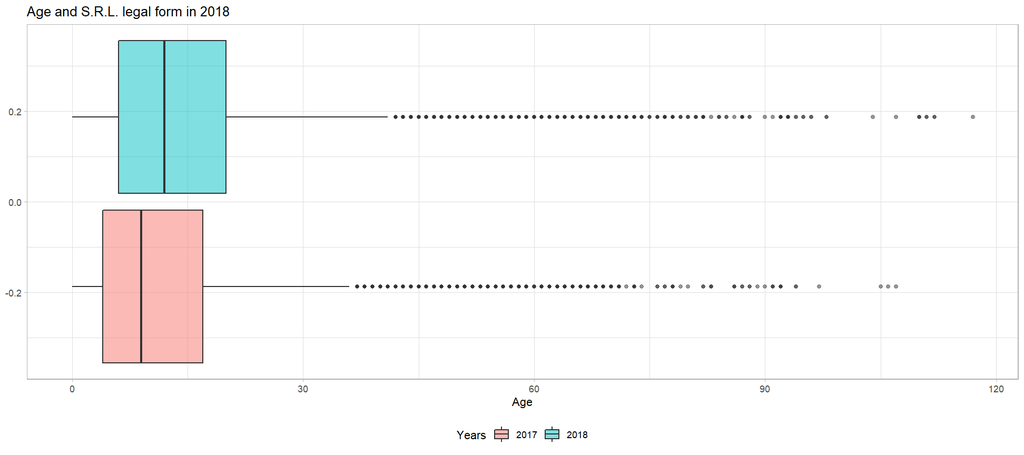

```r
# Distribution of failed companies over the years 2017 and 2018 depending on the legal form
ggplot(aida1718F[aida1718F$`Legal form` == 'S.R.L.',], aes(x=Age, group=as.factor(`Last accounting closing date`), fill=as.factor(`Last accounting closing date`))) +
  geom_boxplot(adjust=1, alpha=.5) +
  theme_light() +
  labs(fill = "Years") +
  theme(legend.position="bottom") +
  ggtitle("Age and S.R.L. legal form in 2018")
```

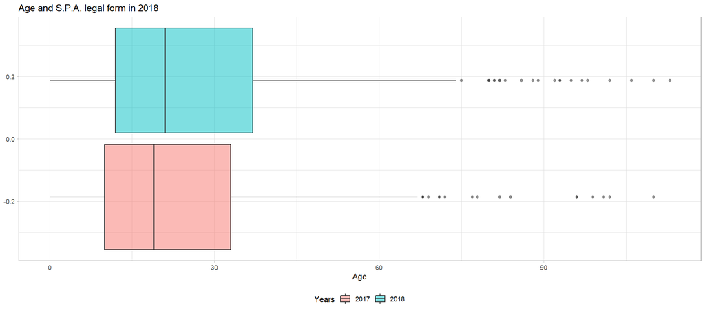

```r
ggplot(aida1718F[aida1718F$`Legal form` == 'S.P.A.',], aes(x=Age, group=as.factor(`Last accounting closing date`), fill=as.factor(`Last accounting closing date`))) +
  geom_boxplot(adjust=1, alpha=.5) +
  theme_light() +
  labs(fill = "Years") +
  theme(legend.position="bottom") +
  ggtitle("Age and S.P.A. legal form in 2018")
```

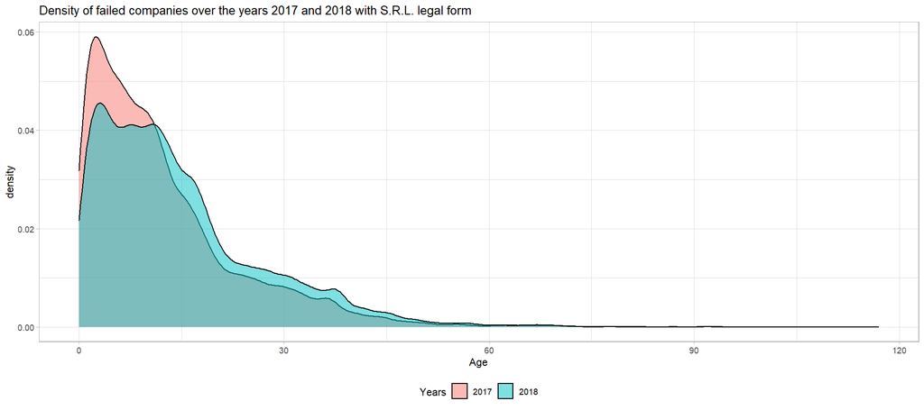

```r
ggplot(data=aida1718F[aida1718F$`Legal form` == 'S.R.L.',], aes(x=Age, group=as.factor(`Last accounting closing date`), fill=as.factor(`Last accounting closing date`))) +
  geom_density(adjust=1, alpha=.5) +
  theme_light() +
  theme(legend.position="bottom") +
  labs(fill = "Years") +
  ggtitle("Density of failed companies over the years 2017 and 2018 with S.R.L. legal form")
```

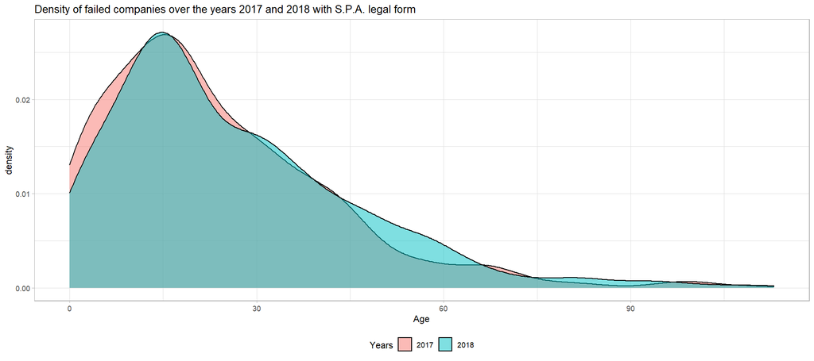

```r
ggplot(data=aida1718F[aida1718F$`Legal form` == 'S.P.A.',], aes(x=Age, group=as.factor(`Last accounting closing date`), fill=as.factor(`Last accounting closing date`))) +
  geom_density(adjust=1, alpha=.5) +
  theme_light() +
  theme(legend.position="bottom") +
  labs(fill = "Years") +
  ggtitle("Density of failed companies over the years 2017 and 2018 with S.P.A. legal form")
```

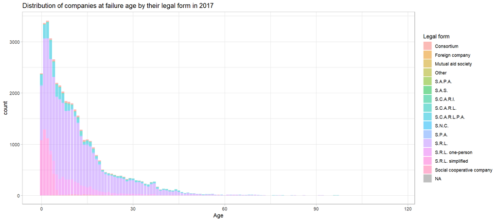

```r
ggplot(aida1718F[aida1718F$`Last accounting closing date`==2017,], aes(x=Age, fill=`Legal form`)) +
  #geom_boxplot(alpha=.5) +
  geom_bar(alpha=.5) +
  theme_light() +
  labs(fill = "Legal form") +
  ggtitle("Distribution of companies at failure age by their legal form in 2017")
```

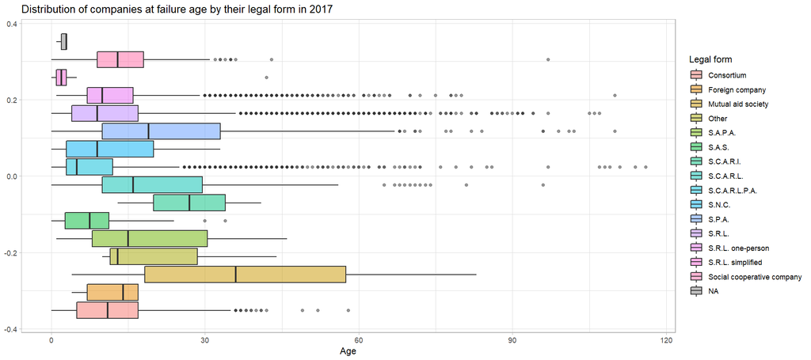

```r
ggplot(aida1718F[aida1718F$`Last accounting closing date`==2017,], aes(x=Age, fill=`Legal form`)) +
  geom_boxplot(alpha=.5) +
  theme_light() +
  labs(fill = "Legal form") +
  ggtitle("Distribution of companies at failure age by their legal form in 2017")
```

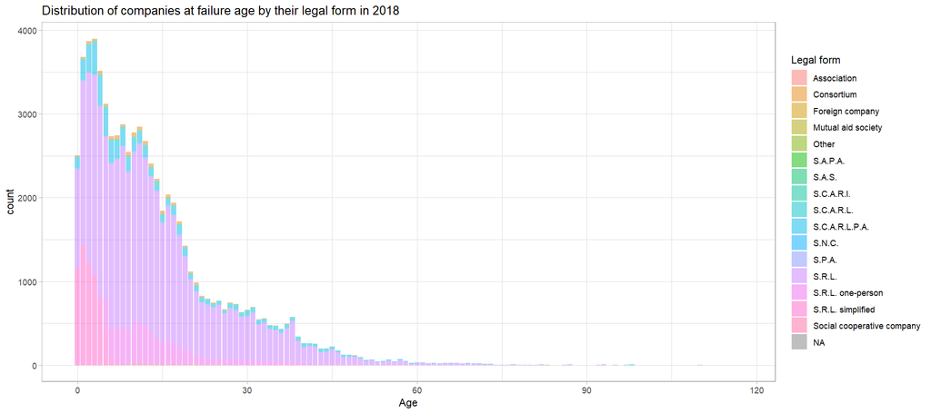

```r
ggplot(aida1718F[aida1718F$`Last accounting closing date`==2018,], aes(x=Age, fill=`Legal form`)) +
  #geom_boxplot(alpha=.5) +
  geom_bar(alpha=.5) +
  theme_light() +
  labs(fill = "Legal form") +
  ggtitle("Distribution of companies at failure age by their legal form in 2018")
```

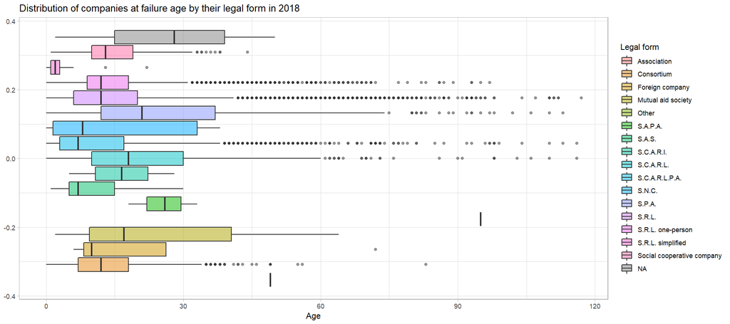

```r
ggplot(aida1718F[aida1718F$`Last accounting closing date`==2018,], aes(x=Age, fill=`Legal form`)) +
  geom_boxplot(alpha=.5) +
  theme_light() +
  labs(fill = "Legal form") +
  ggtitle("Distribution of companies at failure age by their legal form in 2018")
```

```r
# data for statistical tests, age distribution in 2018
company.forms <- unique(aida1718F$`Legal form`)
for(form.name in company.forms){
  print("**************")
  print(form.name)
  print("**************")

  aida1718F.FailedAge17 <- aida1718F[aida1718F$`Last accounting closing date` == 2017 & aida1718F$`Legal form` == form.name,'Age']
  aida1718F.FailedAge18 <- aida1718F[aida1718F$`Last accounting closing date` == 2018 & aida1718F$`Legal form` == form.name,'Age']

  if( length(aida1718F.FailedAge17)>100 & length(aida1718F.FailedAge18)>100 ){
    print(t.test(aida1718F.FailedAge17,aida1718F.FailedAge18,alternative = 'less'))
    print(t.test(aida1718F.FailedAge17,aida1718F.FailedAge18,alternative = 'greater'))
    print("-----")
    print(ks.test(aida1718F.FailedAge17,aida1718F.FailedAge18,alternative = 'less'))
    print(ks.test(aida1718F.FailedAge17,aida1718F.FailedAge18,alternative = 'greater'))
  }
  else print("There are not enough observations")
}
```

```
[1] "**************"
[1] "S.R.L."
[1] "**************"

    Welch Two Sample t-test

data:  aida1718F.FailedAge17 and aida1718F.FailedAge18
t = -28.945, df = 67648, p-value < 2.2e-16
alternative hypothesis: true difference in means is less than 0
95 percent confidence interval:
      -Inf -2.343387
sample estimates:
mean of x mean of y
 12.30527  14.78985


    Welch Two Sample t-test

data:  aida1718F.FailedAge17 and aida1718F.FailedAge18
t = -28.945, df = 67648, p-value = 1
alternative hypothesis: true difference in means is greater than 0
95 percent confidence interval:
 -2.625769       Inf
sample estimates:
mean of x mean of y
 12.30527  14.78985

[1] "-----"
```

```
    Asymptotic two-sample Kolmogorov-Smirnov test

data:  aida1718F.FailedAge17 and aida1718F.FailedAge18
D^- = -7.9689e-17, p-value = 1
alternative hypothesis: the CDF of x lies below that of y
```

```
    Asymptotic two-sample Kolmogorov-Smirnov test

data:  aida1718F.FailedAge17 and aida1718F.FailedAge18
D^+ = 0.1096, p-value < 2.2e-16
alternative hypothesis: the CDF of x lies above that of y

[1] "**************"
[1] "S.C.A.R.L.P.A."
[1] "**************"

    Welch Two Sample t-test

data:  aida1718F.FailedAge17 and aida1718F.FailedAge18
t = -7.9335, df = 6925.9, p-value = 1.234e-15
alternative hypothesis: true difference in means is less than 0
95 percent confidence interval:
    -Inf -2.1086
sample estimates:
mean of x mean of y
 10.24453  12.90475


    Welch Two Sample t-test

data:  aida1718F.FailedAge17 and aida1718F.FailedAge18
t = -7.9335, df = 6925.9, p-value = 1
alternative hypothesis: true difference in means is greater than 0
95 percent confidence interval:
 -3.211837       Inf
sample estimates:
mean of x mean of y
 10.24453  12.90475

[1] "-----"
```

```
    Asymptotic two-sample Kolmogorov-Smirnov test

data:  aida1718F.FailedAge17 and aida1718F.FailedAge18
D^- = 0.0012089, p-value = 0.9949
alternative hypothesis: the CDF of x lies below that of y
```

```
    Asymptotic two-sample Kolmogorov-Smirnov test

data:  aida1718F.FailedAge17 and aida1718F.FailedAge18
D^+ = 0.10166, p-value = 2.22e-16
alternative hypothesis: the CDF of x lies above that of y

[1] "**************"
[1] "S.C.A.R.L."
[1] "**************"

    Welch Two Sample t-test

data:  aida1718F.FailedAge17 and aida1718F.FailedAge18
t = -1.7481, df = 1843.4, p-value = 0.0403
alternative hypothesis: true difference in means is less than 0
95 percent confidence interval:
       -Inf -0.0659873
sample estimates:
mean of x mean of y
 20.22288  21.34877


    Welch Two Sample t-test

data:  aida1718F.FailedAge17 and aida1718F.FailedAge18
t = -1.7481, df = 1843.4, p-value = 0.9597
alternative hypothesis: true difference in means is greater than 0
95 percent confidence interval:
 -2.185788       Inf
sample estimates:
mean of x mean of y
 20.22288  21.34877

[1] "-----"
```

```
    Asymptotic two-sample Kolmogorov-Smirnov test

data:  aida1718F.FailedAge17 and aida1718F.FailedAge18
D^- = 0.0045576, p-value = 0.9783
alternative hypothesis: the CDF of x lies below that of y
```

```
    Asymptotic two-sample Kolmogorov-Smirnov test

data:  aida1718F.FailedAge17 and aida1718F.FailedAge18
D^+ = 0.067626, p-value = 0.007986
alternative hypothesis: the CDF of x lies above that of y

[1] "**************"
[1] "S.R.L. simplified"
[1] "**************"

    Welch Two Sample t-test

data:  aida1718F.FailedAge17 and aida1718F.FailedAge18
t = -13.104, df = 10663, p-value < 2.2e-16
alternative hypothesis: true difference in means is less than 0
95 percent confidence interval:
       -Inf -0.3361795
sample estimates:
mean of x mean of y
 1.691583  2.076021


    Welch Two Sample t-test

data:  aida1718F.FailedAge17 and aida1718F.FailedAge18
t = -13.104, df = 10663, p-value = 1
alternative hypothesis: true difference in means is greater than 0
95 percent confidence interval:
 -0.4326977        Inf
sample estimates:
mean of x mean of y
 1.691583  2.076021

[1] "-----"
```

```
    Asymptotic two-sample Kolmogorov-Smirnov test

data:  aida1718F.FailedAge17 and aida1718F.FailedAge18
D^- = 0.00020938, p-value = 0.9998
alternative hypothesis: the CDF of x lies below that of y
```

```
    Asymptotic two-sample Kolmogorov-Smirnov test

data:  aida1718F.FailedAge17 and aida1718F.FailedAge18
D^+ = 0.10726, p-value < 2.2e-16
alternative hypothesis: the CDF of x lies above that of y

[1] "**************"
[1] "Consortium"
[1] "**************"

    Welch Two Sample t-test

data:  aida1718F.FailedAge17 and aida1718F.FailedAge18
t = -2.7037, df = 1436.9, p-value = 0.003469
alternative hypothesis: true difference in means is less than 0
95 percent confidence interval:
       -Inf -0.5167317
sample estimates:
mean of x mean of y
 12.36503  13.68581


    Welch Two Sample t-test

data:  aida1718F.FailedAge17 and aida1718F.FailedAge18
t = -2.7037, df = 1436.9, p-value = 0.9965
alternative hypothesis: true difference in means is greater than 0
95 percent confidence interval:
 -2.124829       Inf
sample estimates:
mean of x mean of y
 12.36503  13.68581

[1] "-----"
```

```
    Asymptotic two-sample Kolmogorov-Smirnov test

data:  aida1718F.FailedAge17 and aida1718F.FailedAge18
D^- = 0.00040762, p-value = 0.9999
alternative hypothesis: the CDF of x lies below that of y
```

```
    Asymptotic two-sample Kolmogorov-Smirnov test

data:  aida1718F.FailedAge17 and aida1718F.FailedAge18
D^+ = 0.084715, p-value = 0.004534
alternative hypothesis: the CDF of x lies above that of y

[1] "**************"
[1] "Social cooperative company"
[1] "**************"

    Welch Two Sample t-test

data:  aida1718F.FailedAge17 and aida1718F.FailedAge18
t = -0.10146, df = 474.56, p-value = 0.4596
alternative hypothesis: true difference in means is less than 0
95 percent confidence interval:
     -Inf 1.082193
sample estimates:
mean of x mean of y
 14.60558  14.67657


    Welch Two Sample t-test

data:  aida1718F.FailedAge17 and aida1718F.FailedAge18
t = -0.10146, df = 474.56, p-value = 0.5404
alternative hypothesis: true difference in means is greater than 0
95 percent confidence interval:
 -1.224173       Inf
sample estimates:
mean of x mean of y
 14.60558  14.67657

[1] "-----"
```

```
    Asymptotic two-sample Kolmogorov-Smirnov test

data:  aida1718F.FailedAge17 and aida1718F.FailedAge18
D^- = 0.030531, p-value = 0.7742
alternative hypothesis: the CDF of x lies below that of y
```

```
    Asymptotic two-sample Kolmogorov-Smirnov test

data:  aida1718F.FailedAge17 and aida1718F.FailedAge18
D^+ = 0.055501, p-value = 0.4292
alternative hypothesis: the CDF of x lies above that of y

[1] "**************"
[1] "S.R.L. one-person"
[1] "**************"

    Welch Two Sample t-test

data:  aida1718F.FailedAge17 and aida1718F.FailedAge18
t = -10.3, df = 9592, p-value < 2.2e-16
alternative hypothesis: true difference in means is less than 0
95 percent confidence interval:
      -Inf -1.702189
sample estimates:
mean of x mean of y
 13.33272  15.35844


    Welch Two Sample t-test

data:  aida1718F.FailedAge17 and aida1718F.FailedAge18
t = -10.3, df = 9592, p-value = 1
alternative hypothesis: true difference in means is greater than 0
95 percent confidence interval:
 -2.349258       Inf
sample estimates:
mean of x mean of y
 13.33272  15.35844

[1] "-----"
```

```
    Asymptotic two-sample Kolmogorov-Smirnov test

data:  aida1718F.FailedAge17 and aida1718F.FailedAge18
D^- = 0.00029142, p-value = 0.9995
alternative hypothesis: the CDF of x lies below that of y
```

```
    Asymptotic two-sample Kolmogorov-Smirnov test

data:  aida1718F.FailedAge17 and aida1718F.FailedAge18
D^+ = 0.13004, p-value < 2.2e-16
alternative hypothesis: the CDF of x lies above that of y

[1] "**************"
[1] "S.P.A."
[1] "**************"

    Welch Two Sample t-test

data:  aida1718F.FailedAge17 and aida1718F.FailedAge18
t = -2.5372, df = 1295, p-value = 0.005645
alternative hypothesis: true difference in means is less than 0
95 percent confidence interval:
      -Inf -0.909782
sample estimates:
mean of x mean of y
 23.54045  26.13064


    Welch Two Sample t-test

data:  aida1718F.FailedAge17 and aida1718F.FailedAge18
t = -2.5372, df = 1295, p-value = 0.9944
alternative hypothesis: true difference in means is greater than 0
95 percent confidence interval:
 -4.270606       Inf
sample estimates:
mean of x mean of y
 23.54045  26.13064

[1] "-----"
```

```
    Asymptotic two-sample Kolmogorov-Smirnov test

data:  aida1718F.FailedAge17 and aida1718F.FailedAge18
D^- = 0.0032011, p-value = 0.993
alternative hypothesis: the CDF of x lies below that of y
```

```
    Asymptotic two-sample Kolmogorov-Smirnov test

data:  aida1718F.FailedAge17 and aida1718F.FailedAge18
D^+ = 0.061167, p-value = 0.07635
alternative hypothesis: the CDF of x lies above that of y

[1] "**************"
[1] "S.C.A.R.I."
[1] "**************"
[1] "There are not enough observations"
[1] "**************"
[1] "Association"
[1] "**************"
[1] "There are not enough observations"
[1] "**************"
```

[output cut: 22 more lines]

```
Error in t.test.default(aida1718F.FailedAge17, aida1718F.FailedAge18,  :
  not enough 'x' observations
```

### 3.1.2 Age Distribution for specific regions

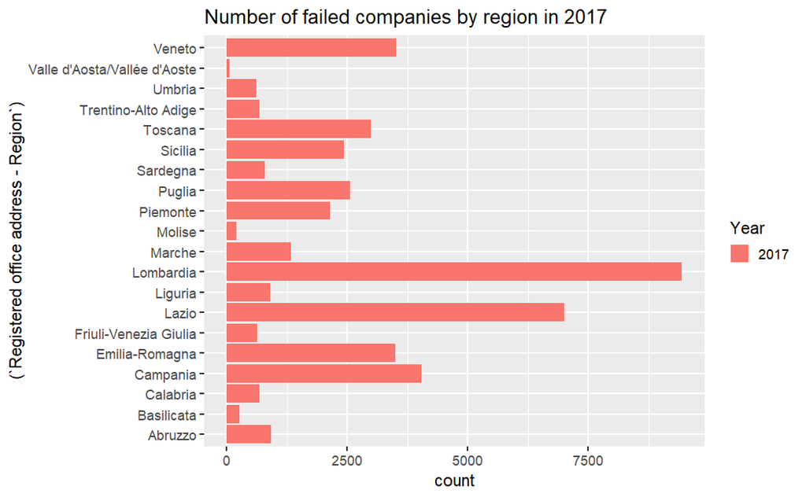

```r
# number of companies by region plot
ggplot(data=aida1718F[aida1718F$`Last accounting closing date`==2017,], aes(x=(`Registered office address - Region`), fill=as.factor(`Last accounting closing date`))) +
  geom_bar() +
  coord_flip() +
  theme(legend.key=element_blank(), legend.key.size=unit(13,"point")) +
  labs(fill = "Year") +
  ggtitle("Number of failed companies by region in 2017")
```

[figure not shown]

```r
ggplot(data=aida1718F[aida1718F$`Last accounting closing date`==2018,], aes(x=fct_infreq(`Registered office address - Region`), group=as.factor(`Last accounting closing date`), fill=`Registered office address - Region`)) +
  geom_bar() +
  coord_flip() +
  theme(legend.key=element_blank(), legend.key.size=unit(13,"point")) +
  labs(fill = "Year") +
  ggtitle("Number of failed companies by region in 2018" )
```

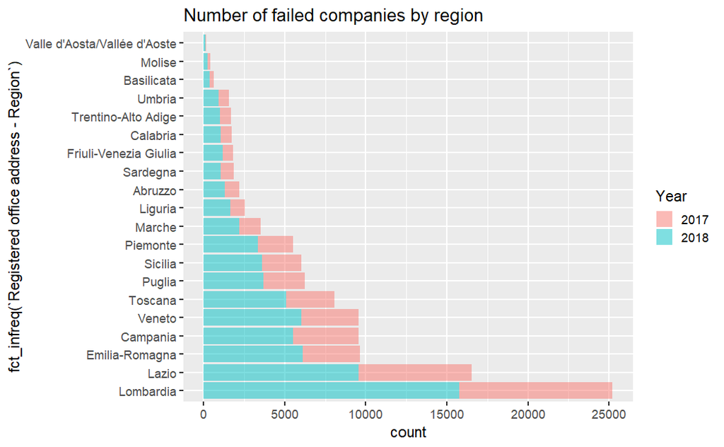

```r
ggplot(data=aida1718F, aes(x=fct_infreq(`Registered office address - Region`), group=as.factor(`Last accounting closing date`), fill=as.factor(`Last accounting closing date`))) +
  geom_bar(alpha=.5) +
  coord_flip() +
  theme(legend.key=element_blank(), legend.key.size=unit(13,"point")) +
  labs(fill = "Year") +
  ggtitle("Number of failed companies by region" )
```

As before with *Legal form*, we inspect the graphs of *Age* and *Specific regions* in search of interesting insights:

```r
# data for statistical tests, region distribution over 2017 and 2018
company.regions <- unique(aida1718F$`Registered office address - Region`)
for(region.name in company.regions){
  print("**************")
  print(region.name)
  print("**************")

  aida2017.FailedAge17 <- aida2017F[aida2017F$`Registered office address - Region` == region.name,"Age"]
  aida2018.FailedAge18 <- aida2018F[aida2018F$`Registered office address - Region` == region.name,"Age"]

  if( length(aida2017.FailedAge17)>100 & length(aida2018.FailedAge18)>100 ){
    print(t.test(aida2017.FailedAge17,aida2018.FailedAge18,alternative = 'less'))
    print(t.test(aida2017.FailedAge17,aida2018.FailedAge18,alternative = 'greater'))
    #print("-----")
    #print(ks.test(aida2017.FailedAge17,aida2018.FailedAge18,alternative = 'less'))
    #print(ks.test(aida2017.FailedAge17,aida2018.FailedAge18,alternative = 'greater'))
  }
  else print("There are not enough observations")
}
```

```
[1] "**************"
[1] "Emilia-Romagna"
[1] "**************"

    Welch Two Sample t-test

data:  aida2017.FailedAge17 and aida2018.FailedAge18
t = -7.468, df = 7713.6, p-value = 4.517e-14
alternative hypothesis: true difference in means is less than 0
95 percent confidence interval:
      -Inf -1.540502
sample estimates:
mean of x mean of y
 12.68687  14.66259


    Welch Two Sample t-test

data:  aida2017.FailedAge17 and aida2018.FailedAge18
t = -7.468, df = 7713.6, p-value = 1
alternative hypothesis: true difference in means is greater than 0
95 percent confidence interval:
 -2.410924       Inf
sample estimates:
mean of x mean of y
 12.68687  14.66259

[1] "**************"
[1] "Sicilia"
[1] "**************"

    Welch Two Sample t-test

data:  aida2017.FailedAge17 and aida2018.FailedAge18
t = -7.7887, df = 5497.9, p-value = 4.02e-15
alternative hypothesis: true difference in means is less than 0
95 percent confidence interval:
      -Inf -1.834059
sample estimates:
mean of x mean of y
```

[output cut: 462 more lines]

```
    Welch Two Sample t-test

data:  aida2017.FailedAge17 and aida2018.FailedAge18
t = -1.7012, df = 394.89, p-value = 0.9552
alternative hypothesis: true difference in means is greater than 0
95 percent confidence interval:
 -3.210674       Inf
sample estimates:
mean of x mean of y
 10.20513  11.83562

[1] "**************"
[1] "Valle d'Aosta/Vallée d'Aoste"
[1] "**************"
[1] "There are not enough observations"
```

## 3.2 Size Distribution

Let us look at the density function of the size feature we obtained before at certain years, from year 2018 backwards

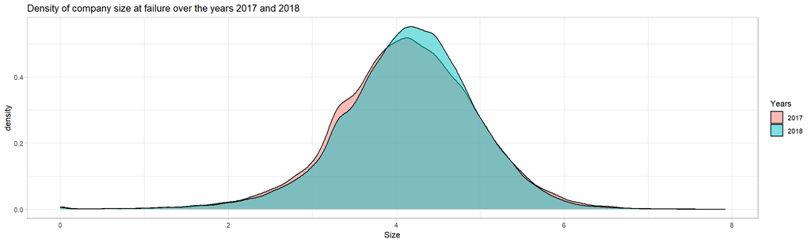

```r
# density of company size at failure over the years 2017 and 2018
ggplot(data=aida1718F, aes(x=Size, group=as.factor(`Last accounting closing date`), fill=as.factor(`Last accounting closing date`))) +
  geom_density(adjust=1, alpha=.5) +
  theme_light() +
  labs(fill = "Years") +
  ggtitle("Density of company size at failure over the years 2017 and 2018")
```

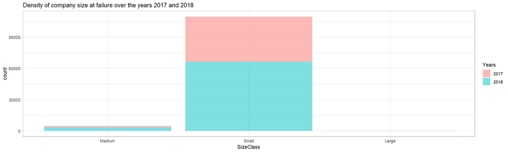

```r
ggplot(data=aida1718F, aes(x=SizeClass, group=as.factor(`Last accounting closing date`), fill=as.factor(`Last accounting closing date`))) +
  geom_bar(alpha=.5) +
  theme_light() +
  labs(fill = "Years") +
  ggtitle("Density of company size at failure over the years 2017 and 2018")
```

```r
# data for statistical tests, age distribution in 2018
aida2017.FailedSize <- aida2017[aida2017$Status=='Failed','Size']
aida2018.FailedSize <- aida2018[aida2018$Status=='Failed','Size']

wilcox.test(aida2017.FailedSize, aida2018.FailedSize, alternative = 'two.sided')
```

```
    Wilcoxon rank sum test with continuity correction

data:  aida2017.FailedSize and aida2018.FailedSize
W = 1519313281, p-value = 1.176e-12
alternative hypothesis: true location shift is not equal to 0
```

```r
wilcox.test(aida2017.FailedSize, aida2018.FailedSize, alternative = 'less')
```

```
    Wilcoxon rank sum test with continuity correction

data:  aida2017.FailedSize and aida2018.FailedSize
W = 1519313281, p-value = 5.882e-13
alternative hypothesis: true location shift is less than 0
```

```r
wilcox.test(aida2017.FailedSize, aida2018.FailedSize, alternative = 'greater')
```

```
    Wilcoxon rank sum test with continuity correction

data:  aida2017.FailedSize and aida2018.FailedSize
W = 1519313281, p-value = 1
alternative hypothesis: true location shift is greater than 0
```

```r
t.test(aida2017.FailedSize, aida2018.FailedSize, alternative = 'two.sided')
```

```
    Welch Two Sample t-test

data:  aida2017.FailedSize and aida2018.FailedSize
t = -5.6326, df = 92031, p-value = 1.781e-08
alternative hypothesis: true difference in means is not equal to 0
95 percent confidence interval:
 -0.03788522 -0.01832538
sample estimates:
mean of x mean of y
 4.124447  4.152553
```

```r
t.test(aida2017.FailedSize, aida2018.FailedSize, alternative = 'less')
```

```
    Welch Two Sample t-test

data:  aida2017.FailedSize and aida2018.FailedSize
t = -5.6326, df = 92031, p-value = 8.903e-09
alternative hypothesis: true difference in means is less than 0
95 percent confidence interval:
        -Inf -0.01989775
sample estimates:
mean of x mean of y
 4.124447  4.152553
```

```r
t.test(aida2017.FailedSize, aida2018.FailedSize, alternative = 'greater')
```

```
    Welch Two Sample t-test

data:  aida2017.FailedSize and aida2018.FailedSize
t = -5.6326, df = 92031, p-value = 1
alternative hypothesis: true difference in means is greater than 0
95 percent confidence interval:
 -0.03631284         Inf
sample estimates:
mean of x mean of y
 4.124447  4.152553
```

```r
ks.test(aida2017.FailedSize, aida2018.FailedSize, alternative = 'two.sided')
```

```
    Asymptotic two-sample Kolmogorov-Smirnov test

data:  aida2017.FailedSize and aida2018.FailedSize
D = 0.030527, p-value < 2.2e-16
alternative hypothesis: two-sided
```

```r
ks.test(aida2017.FailedSize, aida2018.FailedSize, alternative = 'less')
```

```
    Asymptotic two-sample Kolmogorov-Smirnov test

data:  aida2017.FailedSize and aida2018.FailedSize
D^- = 0.0069406, p-value = 0.07254
alternative hypothesis: the CDF of x lies below that of y
```

```r
ks.test(aida2017.FailedSize, aida2018.FailedSize, alternative = 'greater')
```

```
    Asymptotic two-sample Kolmogorov-Smirnov test

data:  aida2017.FailedSize and aida2018.FailedSize
D^+ = 0.030527, p-value < 2.2e-16
alternative hypothesis: the CDF of x lies above that of y
```

```r
rm(aida2017.FailedSize, aida2018.FailedSize)
```

### 3.2.1 Size Distribution for specific company forms

In order to select a company form that would provide us with a statistically significant difference, we decided to take a look at how *Legal form* interacts with *Size*.

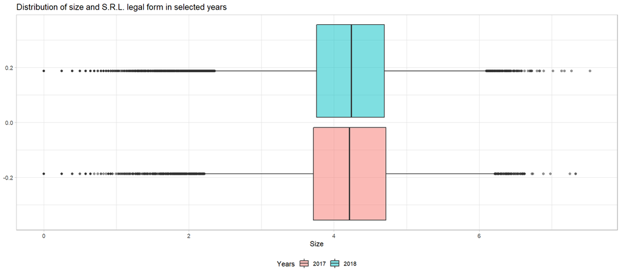

```r
# Distribution of failed companies over the years 2017 and 2018 depending on the legal form
ggplot(aida1718F[aida1718F$`Legal form` == 'S.R.L.',], aes(x=Size, group=as.factor(`Last accounting closing date`), fill=as.factor(`Last accounting closing date`))) +
  geom_boxplot(alpha=.5) +
  theme_light() +
  labs(fill = "Years") +
  theme(legend.position="bottom") +
  ggtitle("Distribution of size and S.R.L. legal form in selected years")
```

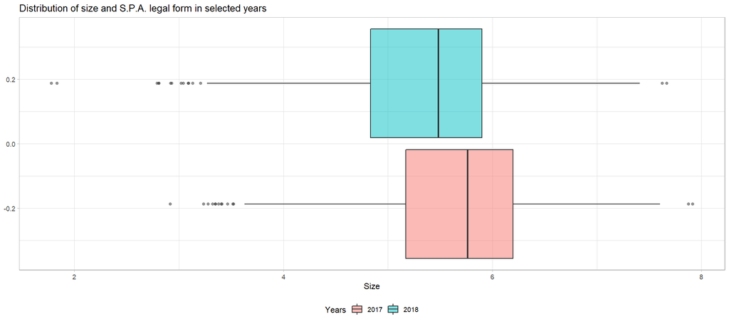

```r
ggplot(aida1718F[aida1718F$`Legal form` == 'S.P.A.',], aes(x=Size, group=as.factor(`Last accounting closing date`), fill=as.factor(`Last accounting closing date`))) +
  geom_boxplot(alpha=.5) +
  theme_light() +
  labs(fill = "Years") +
  theme(legend.position="bottom") +
  ggtitle("Distribution of size and S.P.A. legal form in selected years")
```

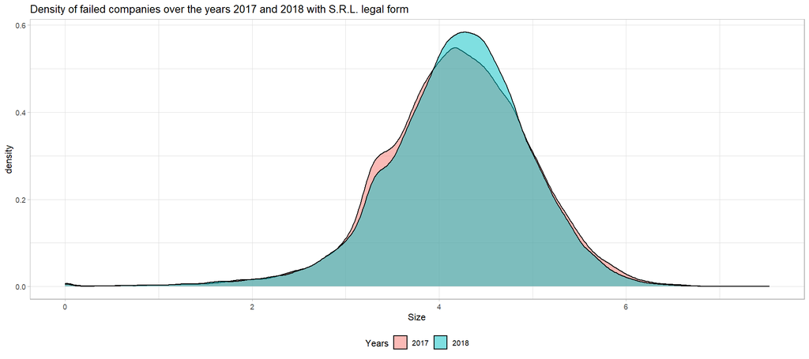

```r
ggplot(data=aida1718F[aida1718F$`Legal form` == 'S.R.L.',], aes(x=Size, group=as.factor(`Last accounting closing date`), fill=as.factor(`Last accounting closing date`))) +
  geom_density(adjust=1, alpha=.5) +
  theme_light() +
  labs(fill = "Years") +
  theme(legend.position="bottom") +
  ggtitle("Density of failed companies over the years 2017 and 2018 with S.R.L. legal form")
```

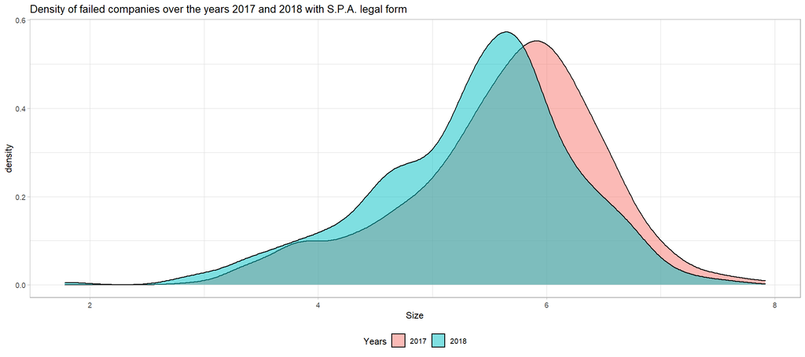

```r
ggplot(data=aida1718F[aida1718F$`Legal form` == 'S.P.A.',], aes(x=Size, group=as.factor(`Last accounting closing date`), fill=as.factor(`Last accounting closing date`))) +
  geom_density(adjust=1, alpha=.5) +
  theme_light() +
  theme(legend.position="bottom") +
  labs(fill = "Years") +
  ggtitle("Density of failed companies over the years 2017 and 2018 with S.P.A. legal form")
```

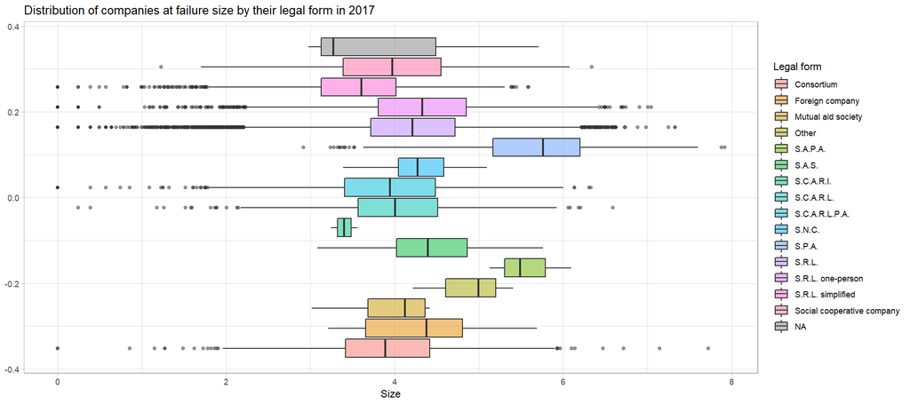

```r
ggplot(aida1718F[aida1718F$`Last accounting closing date`==2017,], aes(x=Size, fill=`Legal form`)) +
  geom_boxplot(alpha=.5) +
  theme_light() +
  labs(fill = "Legal form") +
  ggtitle("Distribution of companies at failure size by their legal form in 2017")
```

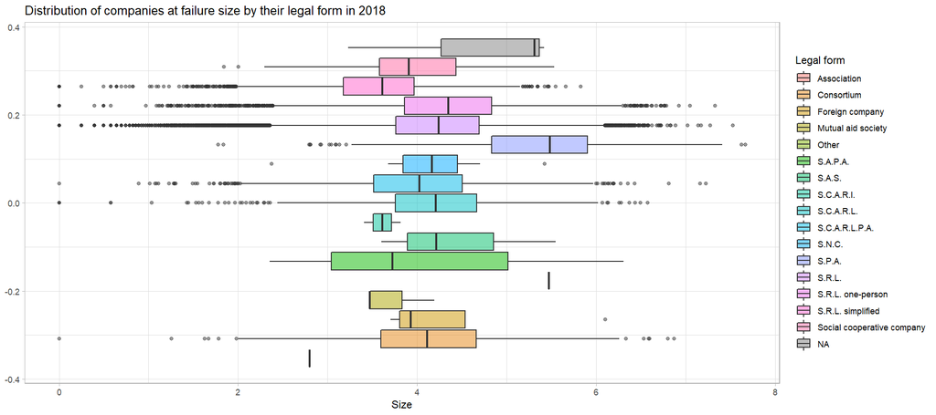

```r
ggplot(aida1718F[aida1718F$`Last accounting closing date`==2018,], aes(x=Size, fill=`Legal form`)) +
  geom_boxplot(alpha=.5) +
  theme_light() +
  labs(fill = "Legal form") +
  ggtitle("Distribution of companies at failure size by their legal form in 2018")
```

```r
# data for statistical tests, age distribution in 2018
company.forms <- unique(aida1718F$`Legal form`)
for(form.name in company.forms){
  print("**************")
  print(form.name)
  print("**************")

  aida1718F.FailedSize17 <- aida1718F[aida1718F$`Last accounting closing date` == 2017 & aida1718F$`Legal form` == form.name,'Size']
  aida1718F.FailedSize18 <- aida1718F[aida1718F$`Last accounting closing date` == 2018 & aida1718F$`Legal form` == form.name,'Size']

  if( length(aida1718F.FailedSize17)>100 & length(aida1718F.FailedSize18)>100 ){
    print(t.test(aida1718F.FailedSize17,aida1718F.FailedSize18,alternative = 'less'))
    print(t.test(aida1718F.FailedSize17,aida1718F.FailedSize18,alternative = 'greater'))
    print("-----")
    print(ks.test(aida1718F.FailedSize17,aida1718F.FailedSize18,alternative = 'less'))
    print(ks.test(aida1718F.FailedSize17,aida1718F.FailedSize18,alternative = 'greater'))
  }
  else print("There are not enough observations")
}
```

```
[1] "**************"
[1] "S.R.L."
[1] "**************"

    Welch Two Sample t-test

data:  aida1718F.FailedSize17 and aida1718F.FailedSize18
t = -1.4239, df = 61964, p-value = 0.07724
alternative hypothesis: true difference in means is less than 0
95 percent confidence interval:
        -Inf 0.001261231
sample estimates:
mean of x mean of y
 4.192964  4.201093


    Welch Two Sample t-test

data:  aida1718F.FailedSize17 and aida1718F.FailedSize18
t = -1.4239, df = 61964, p-value = 0.9228
alternative hypothesis: true difference in means is greater than 0
95 percent confidence interval:
 -0.01751796         Inf
sample estimates:
mean of x mean of y
 4.192964  4.201093

[1] "-----"
```

```
    Asymptotic two-sample Kolmogorov-Smirnov test

data:  aida1718F.FailedSize17 and aida1718F.FailedSize18
D^- = 0.01179, p-value = 0.005573
alternative hypothesis: the CDF of x lies below that of y
```

```
    Asymptotic two-sample Kolmogorov-Smirnov test

data:  aida1718F.FailedSize17 and aida1718F.FailedSize18
D^+ = 0.023091, p-value = 2.263e-09
alternative hypothesis: the CDF of x lies above that of y

[1] "**************"
[1] "S.C.A.R.L.P.A."
[1] "**************"

    Welch Two Sample t-test

data:  aida1718F.FailedSize17 and aida1718F.FailedSize18
t = -3.601, df = 6393, p-value = 0.0001597
alternative hypothesis: true difference in means is less than 0
95 percent confidence interval:
       -Inf -0.0369193
sample estimates:
mean of x mean of y
 3.921008  3.988979


    Welch Two Sample t-test

data:  aida1718F.FailedSize17 and aida1718F.FailedSize18
t = -3.601, df = 6393, p-value = 0.9998
alternative hypothesis: true difference in means is greater than 0
95 percent confidence interval:
 -0.09902337         Inf
sample estimates:
mean of x mean of y
 3.921008  3.988979

[1] "-----"
```

```
    Asymptotic two-sample Kolmogorov-Smirnov test

data:  aida1718F.FailedSize17 and aida1718F.FailedSize18
D^- = 0.0077169, p-value = 0.8133
alternative hypothesis: the CDF of x lies below that of y
```

```
    Asymptotic two-sample Kolmogorov-Smirnov test

data:  aida1718F.FailedSize17 and aida1718F.FailedSize18
D^+ = 0.046443, p-value = 0.0005625
alternative hypothesis: the CDF of x lies above that of y

[1] "**************"
[1] "S.C.A.R.L."
[1] "**************"

    Welch Two Sample t-test

data:  aida1718F.FailedSize17 and aida1718F.FailedSize18
t = -4.7825, df = 1770, p-value = 9.373e-07
alternative hypothesis: true difference in means is less than 0
95 percent confidence interval:
       -Inf -0.1066677
sample estimates:
mean of x mean of y
 4.017798  4.180429


    Welch Two Sample t-test

data:  aida1718F.FailedSize17 and aida1718F.FailedSize18
t = -4.7825, df = 1770, p-value = 1
alternative hypothesis: true difference in means is greater than 0
95 percent confidence interval:
 -0.2185941        Inf
sample estimates:
mean of x mean of y
 4.017798  4.180429

[1] "-----"
```

```
    Asymptotic two-sample Kolmogorov-Smirnov test

data:  aida1718F.FailedSize17 and aida1718F.FailedSize18
D^- = 0.0021053, p-value = 0.9953
alternative hypothesis: the CDF of x lies below that of y
```

```
    Asymptotic two-sample Kolmogorov-Smirnov test

data:  aida1718F.FailedSize17 and aida1718F.FailedSize18
D^+ = 0.12432, p-value = 8.14e-08
alternative hypothesis: the CDF of x lies above that of y

[1] "**************"
[1] "S.R.L. simplified"
[1] "**************"

    Welch Two Sample t-test

data:  aida1718F.FailedSize17 and aida1718F.FailedSize18
t = -0.033704, df = 9919.3, p-value = 0.4866
alternative hypothesis: true difference in means is less than 0
95 percent confidence interval:
       -Inf 0.02151483
sample estimates:
mean of x mean of y
 3.542432  3.542882


    Welch Two Sample t-test

data:  aida1718F.FailedSize17 and aida1718F.FailedSize18
t = -0.033704, df = 9919.3, p-value = 0.5134
alternative hypothesis: true difference in means is greater than 0
95 percent confidence interval:
 -0.0224149        Inf
sample estimates:
mean of x mean of y
 3.542432  3.542882

[1] "-----"
```

```
    Asymptotic two-sample Kolmogorov-Smirnov test

data:  aida1718F.FailedSize17 and aida1718F.FailedSize18
D^- = 0.032777, p-value = 0.003109
alternative hypothesis: the CDF of x lies below that of y
```

```
    Asymptotic two-sample Kolmogorov-Smirnov test

data:  aida1718F.FailedSize17 and aida1718F.FailedSize18
D^+ = 0.022992, p-value = 0.05838
alternative hypothesis: the CDF of x lies above that of y

[1] "**************"
[1] "Consortium"
[1] "**************"

    Welch Two Sample t-test

data:  aida1718F.FailedSize17 and aida1718F.FailedSize18
t = -4.8322, df = 1339.2, p-value = 7.528e-07
alternative hypothesis: true difference in means is less than 0
95 percent confidence interval:
       -Inf -0.1399808
sample estimates:
mean of x mean of y
 3.921755  4.134049


    Welch Two Sample t-test

data:  aida1718F.FailedSize17 and aida1718F.FailedSize18
t = -4.8322, df = 1339.2, p-value = 1
alternative hypothesis: true difference in means is greater than 0
95 percent confidence interval:
 -0.2846067        Inf
sample estimates:
mean of x mean of y
 3.921755  4.134049

[1] "-----"
```

```
    Asymptotic two-sample Kolmogorov-Smirnov test

data:  aida1718F.FailedSize17 and aida1718F.FailedSize18
D^- = 0.0048914, p-value = 0.9822
alternative hypothesis: the CDF of x lies below that of y
```

```
    Asymptotic two-sample Kolmogorov-Smirnov test

data:  aida1718F.FailedSize17 and aida1718F.FailedSize18
D^+ = 0.12717, p-value = 5.236e-06
alternative hypothesis: the CDF of x lies above that of y

[1] "**************"
[1] "Social cooperative company"
[1] "**************"

    Welch Two Sample t-test

data:  aida1718F.FailedSize17 and aida1718F.FailedSize18
t = -0.18563, df = 467.55, p-value = 0.4264
alternative hypothesis: true difference in means is less than 0
95 percent confidence interval:
      -Inf 0.0972822
sample estimates:
mean of x mean of y
 3.945084  3.957432


    Welch Two Sample t-test

data:  aida1718F.FailedSize17 and aida1718F.FailedSize18
t = -0.18563, df = 467.55, p-value = 0.5736
alternative hypothesis: true difference in means is greater than 0
95 percent confidence interval:
 -0.121978       Inf
sample estimates:
mean of x mean of y
 3.945084  3.957432

[1] "-----"

    Asymptotic two-sample Kolmogorov-Smirnov test

data:  aida1718F.FailedSize17 and aida1718F.FailedSize18
D^- = 0.092699, p-value = 0.09449
alternative hypothesis: the CDF of x lies below that of y
```

[output cut: 21 more lines]

```
 4.288209  4.301040


    Welch Two Sample t-test

data:  aida1718F.FailedSize17 and aida1718F.FailedSize18
t = -0.78265, df = 8994.3, p-value = 0.7831
alternative hypothesis: true difference in means is greater than 0
95 percent confidence interval:
 -0.03980052         Inf
sample estimates:
mean of x mean of y
 4.288209  4.301040

[1] "-----"
```

```
    Asymptotic two-sample Kolmogorov-Smirnov test

data:  aida1718F.FailedSize17 and aida1718F.FailedSize18
D^- = 0.014507, p-value = 0.3261
alternative hypothesis: the CDF of x lies below that of y
```

```
    Asymptotic two-sample Kolmogorov-Smirnov test

data:  aida1718F.FailedSize17 and aida1718F.FailedSize18
D^+ = 0.0242, p-value = 0.04425
alternative hypothesis: the CDF of x lies above that of y

[1] "**************"
[1] "S.P.A."
[1] "**************"

    Welch Two Sample t-test

data:  aida1718F.FailedSize17 and aida1718F.FailedSize18
t = 5.5598, df = 1260.1, p-value = 1
alternative hypothesis: true difference in means is less than 0
95 percent confidence interval:
     -Inf 0.335726
sample estimates:
mean of x mean of y
 5.625390  5.366355


    Welch Two Sample t-test

data:  aida1718F.FailedSize17 and aida1718F.FailedSize18
t = 5.5598, df = 1260.1, p-value = 1.647e-08
alternative hypothesis: true difference in means is greater than 0
95 percent confidence interval:
 0.1823435       Inf
sample estimates:
mean of x mean of y
 5.625390  5.366355

[1] "-----"
```

```
    Asymptotic two-sample Kolmogorov-Smirnov test

data:  aida1718F.FailedSize17 and aida1718F.FailedSize18
D^- = 0.1792, p-value = 2.578e-10
alternative hypothesis: the CDF of x lies below that of y
```

```
    Asymptotic two-sample Kolmogorov-Smirnov test

data:  aida1718F.FailedSize17 and aida1718F.FailedSize18
D^+ = -1.0192e-17, p-value = 1
alternative hypothesis: the CDF of x lies above that of y

[1] "**************"
[1] "S.C.A.R.I."
[1] "**************"
[1] "There are not enough observations"
[1] "**************"
[1] "Association"
[1] "**************"
[1] "There are not enough observations"
[1] "**************"
```

[output cut: 22 more lines]

```
Error in t.test.default(aida1718F.FailedSize17, aida1718F.FailedSize18,  :
  not enough 'x' observations
```

As before with *Legal form*, we inspect the graphs of *Size* and *Specific regions* in search of interesting insights:

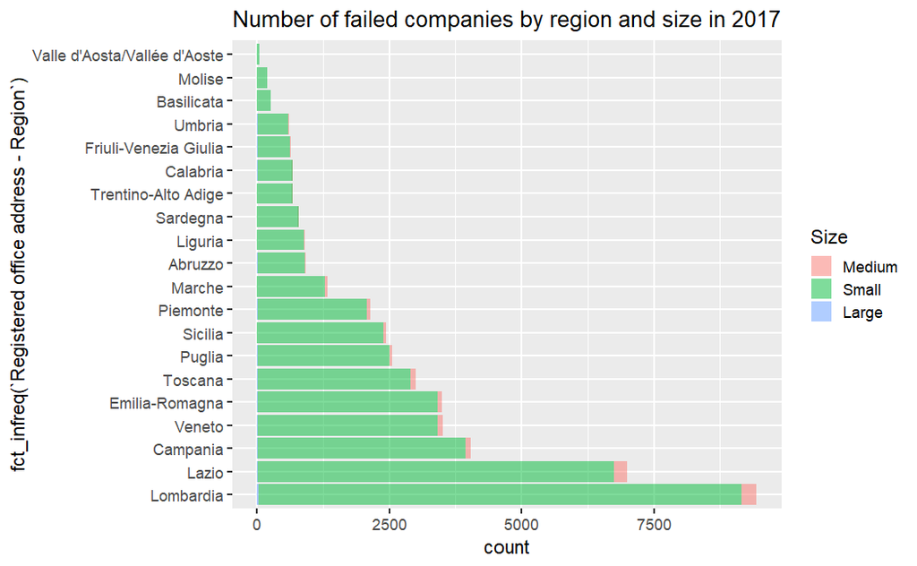

```r
# number of companies by region plot
ggplot(data=aida1718F[aida1718F$`Last accounting closing date`==2017,], aes(x=fct_infreq(`Registered office address - Region`), fill=SizeClass)) +
  geom_bar(alpha=0.5) +
  coord_flip() +
  theme(legend.key=element_blank(), legend.key.size=unit(13,"point")) +
  labs(fill = "Size") +
  ggtitle("Number of failed companies by region and size in 2017")
```

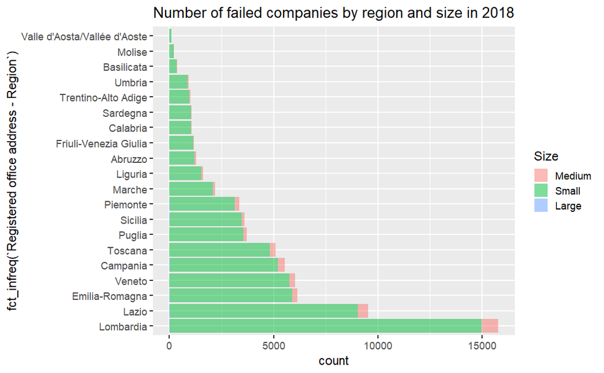

```r
ggplot(data=aida1718F[aida1718F$`Last accounting closing date`==2018,], aes(x=fct_infreq(`Registered office address - Region`), fill=SizeClass)) +
  geom_bar(alpha=0.5) +
  coord_flip() +
  theme(legend.key=element_blank(), legend.key.size=unit(13,"point")) +
  labs(fill = "Size") +
  ggtitle("Number of failed companies by region and size in 2018" )
```

```r
# data for statistical tests, region distribution over 2017 and 2018
company.regions <- unique(aida1718F$`Registered office address - Region`)
for(region.name in company.regions){
  print("**************")
  print(region.name)
  print("**************")

  aida2017.FailedSize17 <- aida2017F[aida2017F$`Registered office address - Region` == region.name,"Size"]
  aida2018.FailedSize18 <- aida2018F[aida2018F$`Registered office address - Region` == region.name,"Size"]

  if( length(aida2017.FailedSize17)>100 & length(aida2018.FailedSize18)>100 ){
    print(t.test(aida2017.FailedSize17,aida2018.FailedSize18,alternative = 'less'))
    print(t.test(aida2017.FailedSize17,aida2018.FailedSize18,alternative = 'greater'))
    print("-----")
    print(ks.test(aida2017.FailedSize17,aida2018.FailedSize18,alternative = 'less'))
    print(ks.test(aida2017.FailedSize17,aida2018.FailedSize18,alternative = 'greater'))
  }
  else print("There are not enough observations")
}
```

```
[1] "**************"
[1] "Emilia-Romagna"
[1] "**************"

    Welch Two Sample t-test

data:  aida2017.FailedSize17 and aida2018.FailedSize18
t = -1.5324, df = 6933.1, p-value = 0.06273
alternative hypothesis: true difference in means is less than 0
95 percent confidence interval:
        -Inf 0.001961791
sample estimates:
mean of x mean of y
 4.204078  4.230769


    Welch Two Sample t-test

data:  aida2017.FailedSize17 and aida2018.FailedSize18
t = -1.5324, df = 6933.1, p-value = 0.9373
alternative hypothesis: true difference in means is greater than 0
95 percent confidence interval:
 -0.05534197         Inf
sample estimates:
mean of x mean of y
 4.204078  4.230769

[1] "-----"
```

```
    Asymptotic two-sample Kolmogorov-Smirnov test

data:  aida2017.FailedSize17 and aida2018.FailedSize18
D^- = 0.012401, p-value = 0.5042
alternative hypothesis: the CDF of x lies below that of y
```

```
    Asymptotic two-sample Kolmogorov-Smirnov test

data:  aida2017.FailedSize17 and aida2018.FailedSize18
D^+ = 0.027306, p-value = 0.03614
alternative hypothesis: the CDF of x lies above that of y

[1] "**************"
[1] "Sicilia"
[1] "**************"

    Welch Two Sample t-test

data:  aida2017.FailedSize17 and aida2018.FailedSize18
t = -4.1858, df = 4957, p-value = 1.445e-05
alternative hypothesis: true difference in means is less than 0
95 percent confidence interval:
        -Inf -0.05406703
sample estimates:
mean of x mean of y
 4.022132  4.111209


    Welch Two Sample t-test

data:  aida2017.FailedSize17 and aida2018.FailedSize18
t = -4.1858, df = 4957, p-value = 1
alternative hypothesis: true difference in means is greater than 0
95 percent confidence interval:
 -0.1240881        Inf
sample estimates:
mean of x mean of y
 4.022132  4.111209

[1] "-----"
```

```
    Asymptotic two-sample Kolmogorov-Smirnov test

data:  aida2017.FailedSize17 and aida2018.FailedSize18
D^- = 0.0031807, p-value = 0.9711
alternative hypothesis: the CDF of x lies below that of y
```

```
    Asymptotic two-sample Kolmogorov-Smirnov test

data:  aida2017.FailedSize17 and aida2018.FailedSize18
D^+ = 0.06169, p-value = 1.598e-05
alternative hypothesis: the CDF of x lies above that of y

[1] "**************"
[1] "Toscana"
[1] "**************"

    Welch Two Sample t-test

data:  aida2017.FailedSize17 and aida2018.FailedSize18
t = 0.18016, df = 6213.1, p-value = 0.5715
alternative hypothesis: true difference in means is less than 0
95 percent confidence interval:
       -Inf 0.03473648
sample estimates:
mean of x mean of y
 4.127460  4.124032


    Welch Two Sample t-test

data:  aida2017.FailedSize17 and aida2018.FailedSize18
t = 0.18016, df = 6213.1, p-value = 0.4285
alternative hypothesis: true difference in means is greater than 0
95 percent confidence interval:
 -0.02787924         Inf
sample estimates:
mean of x mean of y
 4.127460  4.124032

[1] "-----"
```

```
    Asymptotic two-sample Kolmogorov-Smirnov test

data:  aida2017.FailedSize17 and aida2018.FailedSize18
D^- = 0.019182, p-value = 0.2499
alternative hypothesis: the CDF of x lies below that of y
```

```
    Asymptotic two-sample Kolmogorov-Smirnov test

data:  aida2017.FailedSize17 and aida2018.FailedSize18
D^+ = 0.025443, p-value = 0.08721
alternative hypothesis: the CDF of x lies above that of y

[1] "**************"
[1] "Puglia"
[1] "**************"

    Welch Two Sample t-test

data:  aida2017.FailedSize17 and aida2018.FailedSize18
t = -2.9813, df = 5333.7, p-value = 0.001441
alternative hypothesis: true difference in means is less than 0
95 percent confidence interval:
        -Inf -0.02736623
sample estimates:
mean of x mean of y
 3.961596  4.022656


    Welch Two Sample t-test

data:  aida2017.FailedSize17 and aida2018.FailedSize18
t = -2.9813, df = 5333.7, p-value = 0.9986
alternative hypothesis: true difference in means is greater than 0
95 percent confidence interval:
 -0.09475302         Inf
sample estimates:
mean of x mean of y
 3.961596  4.022656

[1] "-----"
```

```
    Asymptotic two-sample Kolmogorov-Smirnov test

data:  aida2017.FailedSize17 and aida2018.FailedSize18
D^- = 0.0028397, p-value = 0.9759
alternative hypothesis: the CDF of x lies below that of y
```

```
    Asymptotic two-sample Kolmogorov-Smirnov test

data:  aida2017.FailedSize17 and aida2018.FailedSize18
D^+ = 0.035125, p-value = 0.02401
alternative hypothesis: the CDF of x lies above that of y

[1] "**************"
[1] "Marche"
[1] "**************"

    Welch Two Sample t-test

data:  aida2017.FailedSize17 and aida2018.FailedSize18
t = -2.6676, df = 2716.9, p-value = 0.003842
alternative hypothesis: true difference in means is less than 0
95 percent confidence interval:
        -Inf -0.02920434
sample estimates:
mean of x mean of y
 4.066579  4.142792


    Welch Two Sample t-test

data:  aida2017.FailedSize17 and aida2018.FailedSize18
t = -2.6676, df = 2716.9, p-value = 0.9962
alternative hypothesis: true difference in means is greater than 0
95 percent confidence interval:
 -0.1232216        Inf
sample estimates:
mean of x mean of y
 4.066579  4.142792

[1] "-----"
```

```
    Asymptotic two-sample Kolmogorov-Smirnov test

data:  aida2017.FailedSize17 and aida2018.FailedSize18
D^- = 0.008921, p-value = 0.8766
alternative hypothesis: the CDF of x lies below that of y
```

```
    Asymptotic two-sample Kolmogorov-Smirnov test

data:  aida2017.FailedSize17 and aida2018.FailedSize18
D^+ = 0.067333, p-value = 0.00055
alternative hypothesis: the CDF of x lies above that of y

[1] "**************"
[1] "Lombardia"
[1] "**************"

    Welch Two Sample t-test

data:  aida2017.FailedSize17 and aida2018.FailedSize18
t = -1.8561, df = 18635, p-value = 0.03173
alternative hypothesis: true difference in means is less than 0
95 percent confidence interval:
         -Inf -0.002328493
sample estimates:
mean of x mean of y
 4.220060  4.240527


    Welch Two Sample t-test

data:  aida2017.FailedSize17 and aida2018.FailedSize18
t = -1.8561, df = 18635, p-value = 0.9683
alternative hypothesis: true difference in means is greater than 0
95 percent confidence interval:
 -0.03860537         Inf
sample estimates:
mean of x mean of y
 4.220060  4.240527

[1] "-----"
```

```
    Asymptotic two-sample Kolmogorov-Smirnov test

data:  aida2017.FailedSize17 and aida2018.FailedSize18
D^- = 0.01767, p-value = 0.025
alternative hypothesis: the CDF of x lies below that of y
```

```
    Asymptotic two-sample Kolmogorov-Smirnov test

data:  aida2017.FailedSize17 and aida2018.FailedSize18
D^+ = 0.037034, p-value = 9.179e-08
alternative hypothesis: the CDF of x lies above that of y

[1] "**************"
[1] "Calabria"
[1] "**************"

    Welch Two Sample t-test

data:  aida2017.FailedSize17 and aida2018.FailedSize18
t = -0.46414, df = 1376.5, p-value = 0.3213
alternative hypothesis: true difference in means is less than 0
95 percent confidence interval:
       -Inf 0.04923247
sample estimates:
mean of x mean of y
 4.030235  4.049571


    Welch Two Sample t-test

data:  aida2017.FailedSize17 and aida2018.FailedSize18
t = -0.46414, df = 1376.5, p-value = 0.6787
alternative hypothesis: true difference in means is greater than 0
95 percent confidence interval:
 -0.08790314         Inf
sample estimates:
mean of x mean of y
 4.030235  4.049571

[1] "-----"
```

```
    Asymptotic two-sample Kolmogorov-Smirnov test

data:  aida2017.FailedSize17 and aida2018.FailedSize18
D^- = 0.025991, p-value = 0.5721
alternative hypothesis: the CDF of x lies below that of y
```

```
    Asymptotic two-sample Kolmogorov-Smirnov test

data:  aida2017.FailedSize17 and aida2018.FailedSize18
D^+ = 0.039255, p-value = 0.2798
alternative hypothesis: the CDF of x lies above that of y

[1] "**************"
[1] "Umbria"
[1] "**************"

    Welch Two Sample t-test

data:  aida2017.FailedSize17 and aida2018.FailedSize18
t = 1.0118, df = 1301.6, p-value = 0.8441
alternative hypothesis: true difference in means is less than 0
95 percent confidence interval:
      -Inf 0.1127614
sample estimates:
mean of x mean of y
 4.055258  4.012332


    Welch Two Sample t-test

data:  aida2017.FailedSize17 and aida2018.FailedSize18
t = 1.0118, df = 1301.6, p-value = 0.1559
alternative hypothesis: true difference in means is greater than 0
95 percent confidence interval:
 -0.02690768         Inf
sample estimates:
mean of x mean of y
 4.055258  4.012332

[1] "-----"
```

```
    Asymptotic two-sample Kolmogorov-Smirnov test

data:  aida2017.FailedSize17 and aida2018.FailedSize18
D^- = 0.056791, p-value = 0.09285
alternative hypothesis: the CDF of x lies below that of y
```

```
    Asymptotic two-sample Kolmogorov-Smirnov test

data:  aida2017.FailedSize17 and aida2018.FailedSize18
D^+ = 0.045741, p-value = 0.214
alternative hypothesis: the CDF of x lies above that of y

[1] "**************"
[1] "Lazio"
[1] "**************"

    Welch Two Sample t-test

data:  aida2017.FailedSize17 and aida2018.FailedSize18
t = -0.26275, df = 14779, p-value = 0.3964
alternative hypothesis: true difference in means is less than 0
95 percent confidence interval:
       -Inf 0.01769189
sample estimates:
mean of x mean of y
 4.070170  4.073533


    Welch Two Sample t-test

data:  aida2017.FailedSize17 and aida2018.FailedSize18
t = -0.26275, df = 14779, p-value = 0.6036
alternative hypothesis: true difference in means is greater than 0
95 percent confidence interval:
 -0.02441802         Inf
sample estimates:
mean of x mean of y
 4.070170  4.073533

[1] "-----"
```

```
    Asymptotic two-sample Kolmogorov-Smirnov test

data:  aida2017.FailedSize17 and aida2018.FailedSize18
D^- = 0.014123, p-value = 0.1998
alternative hypothesis: the CDF of x lies below that of y
```

```
    Asymptotic two-sample Kolmogorov-Smirnov test

data:  aida2017.FailedSize17 and aida2018.FailedSize18
D^+ = 0.017655, p-value = 0.08076
alternative hypothesis: the CDF of x lies above that of y

[1] "**************"
[1] "Campania"
[1] "**************"

    Welch Two Sample t-test

data:  aida2017.FailedSize17 and aida2018.FailedSize18
t = -1.8013, df = 8531.4, p-value = 0.03584
alternative hypothesis: true difference in means is less than 0
95 percent confidence interval:
         -Inf -0.002497698
sample estimates:
mean of x mean of y
 4.114898  4.143684


    Welch Two Sample t-test

data:  aida2017.FailedSize17 and aida2018.FailedSize18
t = -1.8013, df = 8531.4, p-value = 0.9642
alternative hypothesis: true difference in means is greater than 0
95 percent confidence interval:
 -0.05507337         Inf
sample estimates:
mean of x mean of y
 4.114898  4.143684

[1] "-----"
```

```
    Asymptotic two-sample Kolmogorov-Smirnov test

data:  aida2017.FailedSize17 and aida2018.FailedSize18
D^- = 0.0097305, p-value = 0.643
alternative hypothesis: the CDF of x lies below that of y
```

```
    Asymptotic two-sample Kolmogorov-Smirnov test

data:  aida2017.FailedSize17 and aida2018.FailedSize18
D^+ = 0.032615, p-value = 0.007005
alternative hypothesis: the CDF of x lies above that of y

[1] "**************"
[1] "Liguria"
[1] "**************"

    Welch Two Sample t-test

data:  aida2017.FailedSize17 and aida2018.FailedSize18
t = -1.2977, df = 1748.3, p-value = 0.09728
alternative hypothesis: true difference in means is less than 0
95 percent confidence interval:
      -Inf 0.0119222
sample estimates:
mean of x mean of y
 4.108277  4.152733


    Welch Two Sample t-test

data:  aida2017.FailedSize17 and aida2018.FailedSize18
t = -1.2977, df = 1748.3, p-value = 0.9027
alternative hypothesis: true difference in means is greater than 0
95 percent confidence interval:
 -0.1008358        Inf
sample estimates:
mean of x mean of y
 4.108277  4.152733

[1] "-----"
```

```
    Asymptotic two-sample Kolmogorov-Smirnov test

data:  aida2017.FailedSize17 and aida2018.FailedSize18
D^- = 0.017735, p-value = 0.6931
alternative hypothesis: the CDF of x lies below that of y
```

```
    Asymptotic two-sample Kolmogorov-Smirnov test

data:  aida2017.FailedSize17 and aida2018.FailedSize18
D^+ = 0.044984, p-value = 0.09456
alternative hypothesis: the CDF of x lies above that of y

[1] "**************"
[1] "Sardegna"
[1] "**************"

    Welch Two Sample t-test

data:  aida2017.FailedSize17 and aida2018.FailedSize18
t = -2.376, df = 1713.6, p-value = 0.008805
alternative hypothesis: true difference in means is less than 0
95 percent confidence interval:
        -Inf -0.02717846
sample estimates:
mean of x mean of y
 4.039587  4.128013


    Welch Two Sample t-test

data:  aida2017.FailedSize17 and aida2018.FailedSize18
t = -2.376, df = 1713.6, p-value = 0.9912
alternative hypothesis: true difference in means is greater than 0
95 percent confidence interval:
 -0.1496737        Inf
sample estimates:
mean of x mean of y
 4.039587  4.128013

[1] "-----"
```

```
    Asymptotic two-sample Kolmogorov-Smirnov test

data:  aida2017.FailedSize17 and aida2018.FailedSize18
D^- = 0.001566, p-value = 0.9978
alternative hypothesis: the CDF of x lies below that of y
```

```
    Asymptotic two-sample Kolmogorov-Smirnov test

data:  aida2017.FailedSize17 and aida2018.FailedSize18
D^+ = 0.061467, p-value = 0.03262
alternative hypothesis: the CDF of x lies above that of y

[1] "**************"
[1] "Piemonte"
[1] "**************"

    Welch Two Sample t-test

data:  aida2017.FailedSize17 and aida2018.FailedSize18
t = -0.66845, df = 4386, p-value = 0.2519
alternative hypothesis: true difference in means is less than 0
95 percent confidence interval:
      -Inf 0.0221469
sample estimates:
mean of x mean of y
 4.157526  4.172682


    Welch Two Sample t-test

data:  aida2017.FailedSize17 and aida2018.FailedSize18
t = -0.66845, df = 4386, p-value = 0.7481
alternative hypothesis: true difference in means is greater than 0
95 percent confidence interval:
 -0.05245994         Inf
sample estimates:
mean of x mean of y
 4.157526  4.172682

[1] "-----"
```

```
    Asymptotic two-sample Kolmogorov-Smirnov test

data:  aida2017.FailedSize17 and aida2018.FailedSize18
D^- = 0.020865, p-value = 0.3196
alternative hypothesis: the CDF of x lies below that of y
```

```
    Asymptotic two-sample Kolmogorov-Smirnov test

data:  aida2017.FailedSize17 and aida2018.FailedSize18
D^+ = 0.045438, p-value = 0.004474
alternative hypothesis: the CDF of x lies above that of y

[1] "**************"
[1] "Friuli-Venezia Giulia"
[1] "**************"

    Welch Two Sample t-test

data:  aida2017.FailedSize17 and aida2018.FailedSize18
t = 0.58484, df = 1206, p-value = 0.7206
alternative hypothesis: true difference in means is less than 0
95 percent confidence interval:
       -Inf 0.08940398
sample estimates:
mean of x mean of y
 4.128826  4.105389


    Welch Two Sample t-test

data:  aida2017.FailedSize17 and aida2018.FailedSize18
t = 0.58484, df = 1206, p-value = 0.2794
alternative hypothesis: true difference in means is greater than 0
95 percent confidence interval:
 -0.04253016         Inf
sample estimates:
mean of x mean of y
 4.128826  4.105389

[1] "-----"
```

```
    Asymptotic two-sample Kolmogorov-Smirnov test

data:  aida2017.FailedSize17 and aida2018.FailedSize18
D^- = 0.058295, p-value = 0.06108
alternative hypothesis: the CDF of x lies below that of y
```

```
    Asymptotic two-sample Kolmogorov-Smirnov test

data:  aida2017.FailedSize17 and aida2018.FailedSize18
D^+ = 0.038934, p-value = 0.2874
alternative hypothesis: the CDF of x lies above that of y

[1] "**************"
[1] "Veneto"
[1] "**************"

    Welch Two Sample t-test

data:  aida2017.FailedSize17 and aida2018.FailedSize18
t = 0.56127, df = 7299.6, p-value = 0.7127
alternative hypothesis: true difference in means is less than 0
95 percent confidence interval:
       -Inf 0.03839014
sample estimates:
mean of x mean of y
 4.179939  4.170173


    Welch Two Sample t-test

data:  aida2017.FailedSize17 and aida2018.FailedSize18
t = 0.56127, df = 7299.6, p-value = 0.2873
alternative hypothesis: true difference in means is greater than 0
95 percent confidence interval:
 -0.01885793         Inf
sample estimates:
mean of x mean of y
 4.179939  4.170173

[1] "-----"
```

```
    Asymptotic two-sample Kolmogorov-Smirnov test

data:  aida2017.FailedSize17 and aida2018.FailedSize18
D^- = 0.021886, p-value = 0.1192
alternative hypothesis: the CDF of x lies below that of y
```

```
    Asymptotic two-sample Kolmogorov-Smirnov test

data:  aida2017.FailedSize17 and aida2018.FailedSize18
D^+ = 0.033177, p-value = 0.007535
alternative hypothesis: the CDF of x lies above that of y

[1] "**************"
[1] "Trentino-Alto Adige"
[1] "**************"

    Welch Two Sample t-test

data:  aida2017.FailedSize17 and aida2018.FailedSize18
t = -0.63081, df = 1477, p-value = 0.2641
alternative hypothesis: true difference in means is less than 0
95 percent confidence interval:
       -Inf 0.04316873
sample estimates:
mean of x mean of y
 4.214853  4.241680


    Welch Two Sample t-test

data:  aida2017.FailedSize17 and aida2018.FailedSize18
t = -0.63081, df = 1477, p-value = 0.7359
alternative hypothesis: true difference in means is greater than 0
95 percent confidence interval:
 -0.09682207         Inf
sample estimates:
mean of x mean of y
 4.214853  4.241680

[1] "-----"
```

```
    Asymptotic two-sample Kolmogorov-Smirnov test

data:  aida2017.FailedSize17 and aida2018.FailedSize18
D^- = 0.012992, p-value = 0.8724
alternative hypothesis: the CDF of x lies below that of y
```

```
    Asymptotic two-sample Kolmogorov-Smirnov test

data:  aida2017.FailedSize17 and aida2018.FailedSize18
D^+ = 0.036682, p-value = 0.3368
alternative hypothesis: the CDF of x lies above that of y

[1] "**************"
[1] "Basilicata"
[1] "**************"

    Welch Two Sample t-test

data:  aida2017.FailedSize17 and aida2018.FailedSize18
t = -0.91733, df = 571.97, p-value = 0.1797
alternative hypothesis: true difference in means is less than 0
95 percent confidence interval:
       -Inf 0.04536955
sample estimates:
mean of x mean of y
 3.945603  4.002600


    Welch Two Sample t-test

data:  aida2017.FailedSize17 and aida2018.FailedSize18
t = -0.91733, df = 571.97, p-value = 0.8203
alternative hypothesis: true difference in means is greater than 0
95 percent confidence interval:
 -0.1593633        Inf
sample estimates:
mean of x mean of y
 3.945603  4.002600

[1] "-----"
```

```
    Asymptotic two-sample Kolmogorov-Smirnov test

data:  aida2017.FailedSize17 and aida2018.FailedSize18
D^- = 0.012733, p-value = 0.952
alternative hypothesis: the CDF of x lies below that of y
```

```
    Asymptotic two-sample Kolmogorov-Smirnov test

data:  aida2017.FailedSize17 and aida2018.FailedSize18
D^+ = 0.051997, p-value = 0.4404
alternative hypothesis: the CDF of x lies above that of y

[1] "**************"
[1] "Abruzzo"
[1] "**************"

    Welch Two Sample t-test

data:  aida2017.FailedSize17 and aida2018.FailedSize18
t = -1.187, df = 1910.8, p-value = 0.1177
alternative hypothesis: true difference in means is less than 0
95 percent confidence interval:
       -Inf 0.01667098
sample estimates:
mean of x mean of y
 4.004914  4.048057


    Welch Two Sample t-test

data:  aida2017.FailedSize17 and aida2018.FailedSize18
t = -1.187, df = 1910.8, p-value = 0.8823
alternative hypothesis: true difference in means is greater than 0
95 percent confidence interval:
 -0.1029563        Inf
sample estimates:
mean of x mean of y
 4.004914  4.048057

[1] "-----"
```

```
    Asymptotic two-sample Kolmogorov-Smirnov test

data:  aida2017.FailedSize17 and aida2018.FailedSize18
D^- = 0.037406, p-value = 0.2224
alternative hypothesis: the CDF of x lies below that of y
```

```
    Asymptotic two-sample Kolmogorov-Smirnov test

data:  aida2017.FailedSize17 and aida2018.FailedSize18
D^+ = 0.056102, p-value = 0.03401
alternative hypothesis: the CDF of x lies above that of y

[1] "**************"
[1] "Molise"
[1] "**************"

    Welch Two Sample t-test

data:  aida2017.FailedSize17 and aida2018.FailedSize18
t = -0.099045, df = 410.67, p-value = 0.4606
alternative hypothesis: true difference in means is less than 0
95 percent confidence interval:
      -Inf 0.1227156
sample estimates:
mean of x mean of y
 4.051785  4.059629


    Welch Two Sample t-test

data:  aida2017.FailedSize17 and aida2018.FailedSize18
t = -0.099045, df = 410.67, p-value = 0.5394
alternative hypothesis: true difference in means is greater than 0
95 percent confidence interval:
 -0.1384034        Inf
sample estimates:
mean of x mean of y
 4.051785  4.059629

[1] "-----"

    Asymptotic two-sample Kolmogorov-Smirnov test

data:  aida2017.FailedSize17 and aida2018.FailedSize18
D^- = 0.040253, p-value = 0.7159
alternative hypothesis: the CDF of x lies below that of y


    Asymptotic two-sample Kolmogorov-Smirnov test

data:  aida2017.FailedSize17 and aida2018.FailedSize18
D^+ = 0.070952, p-value = 0.354
alternative hypothesis: the CDF of x lies above that of y

[1] "**************"
[1] "Valle d'Aosta/Vallée d'Aoste"
[1] "**************"
[1] "There are not enough observations"
```